# Deep Learning for NLP

Andrés Castro Araújo

August 18, 2019

Taken from Francois Chollet & J.J. Allaire (2018). *Deep Learning with `R` and `Keras`*. Manning Publications.

We can understand how deep-learning works in three stages:

1. Set up the model, which also involves specifying the number of “hidden layers” and parameters (or “weights”)

   AKA *a neural network is parameterized by its weights*.
2. Set up a loss function that quantifies the distance between predictions and observed values.

   AKA *a loss function measures the quality of the network’s output*.
3. Use the backpropagation algorithm to come up with parameters that minimize the loss function.

   AKA *the loss score is used as a feedback signal to adjust the weights*.

Here, we focus on [**`Keras`**](https://keras.rstudio.com/), a framework that provides a convenient way to define and train almost any kind of deep learning model.

The typical `Keras` workflow will look like this:

1. Define your training data: input tensors and target tensors.
2. Define a network of layers (or model) that maps your inputs to your targets.
3. Configure the learning process by choosing a *loss function*, an *optimizer*, and some *metrics* to monitor during training and testing time.
4. Iterate on your training data by calling the `fit()` method of your model.

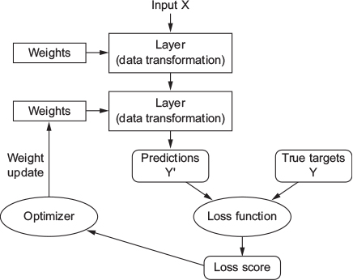

## Basic math and notation

### Glossary

Taken from Chollet (2018: 95-6):

- *Sample* or *input*: One data point that goes into your model.
- *Prediction* or *output*: What comes out of your model.
- *Target*: The truth. What your model should ideally have predicted, according to an external source of data.
- *Prediction error* or *loss value*: A measure of the distance between your model’s prediction and the target.
- *Classes*: A set of possible labels to choose from in a classification problem. For example, when classifying cat and dog pictures, “dog” and “cat” are the two classes.
- *Label*: A specific instance of a class annotation in a classification problem. For instance, if picture #1234 is annotated as containing the class “dog,” then “dog” is a label of picture #1234.
- *Ground-truth* or *annotations*: All targets for a dataset, typically collected by humans.
- *Binary classification*: A classification task where each input sample should be categorized into two exclusive categories.
- *Multiclass classification*: A classification task where each input sample should be categorized into more than two categories: for instance, classifying handwritten digits.
- *Multilabel classification*: A classification task where each input sample can be assigned multiple labels. For instance, a given image may contain both a cat and a dog and should be annotated both with the “cat” label and the “dog” label. The number of labels per image is usually variable.
- *Scalar regression*: A task where the target is a continuous scalar value. Predicting house prices is a good example: the different target prices form a continuous space.
- *Vector regression*: A task where the target is a set of continuous values: for example, a continuous vector. If you’re doing regression against multiple values (such as the coordinates of a bounding box in an image), then you’re doing vector regression.
- *Mini-batch* or *batch*: A small set of samples (typically between 8 and 128) that are processed simultaneously by the model. The number of samples is often a power of 2, to facilitate memory allocation on GPU. When training, a mini-batch is used to compute a single gradient-descent update applied to the weights of the model.

### Tensors

Tensors are multidimensional arrays of data. In other words, they’re a generalization of vectors and matrices to an arbitrary number of dimensions. But don’t be confused with how the word “dimension” is used in linear algebra with how it’s used in the context of tensors.

- In linear algebra, the word “dimension” refers to the “length” or the number of elements inside a vector.
- When talking about tensors, the word “dimension” refers to the “shape” or the number of “axes”. Thus, any $n$-vector is a 1D tensor; any $n \times m$ matrix is a 2D tensor; any $n \times m \times p$ array is a 3D tensor; and so on.

The word **shape** is reserved to describe the number of dimensions a tensor has along each axis. For example, an $n$-vector is a 1D tensor with shape $n$. A 3D tensor can be interpreted visually as a cube of numbers, but it gets hard to visualize higher dimensional arrays.

- A 3D time-series data tensor.

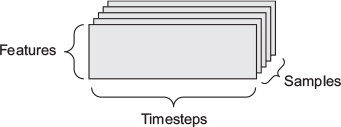

- A 4D image data sensor (channels-first convention).

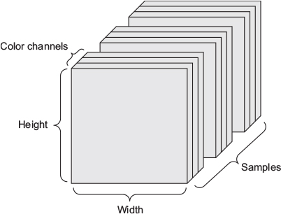

In general, the first axis in all data tensors you’ll come across in deep learning will be the *samples axis* (sometimes called the “samples dimension”), which simply indexes the number of observations. So in an $n \times m$ matrix we are usually looking at $n$ samples (or “units of observations”) with $m$ features each.

### Tensor Operations

All transformations learned by deep neural networks can be reduced to a handful of *tensor operations*.

1. *Element-wise operations* (which may involve tensors of different dimensions, e.g. the `sweep()` function in R or the notion of *broadcasting* in NumPy).
2. *Tensor productos* (i.e. matrix multiplication).
3. *Tensor reshaping* (or rearranging the rows and columns of an array to match a target shape).

   For example:

   ```r
   x <- matrix(0:5, nrow = 3, ncol = 2, byrow = TRUE)
   x
   ```

   ```
        [,1] [,2]
   [1,]    0    1
   [2,]    2    3
   [3,]    4    5
   ```

   ```r
   keras::array_reshape(x, dim = c(2, 3), order = "F")    ## Fortran style
   ```

   ```
        [,1] [,2] [,3]
   [1,]    0    4    3
   [2,]    2    1    5
   ```

   ```r
   keras::array_reshape(x, dim = c(2, 3))                 ## C style
   ```

   ```
        [,1] [,2] [,3]
   [1,]    0    1    2
   [2,]    3    4    5
   ```

   ```r
   t(x)                                                   ## Transpose
   ```

   ```
        [,1] [,2] [,3]
   [1,]    0    2    4
   [2,]    1    3    5
   ```

### The Backpropagation Algorithm

Each layer in a given neural network will look something like this:

$$\underbrace{\mathbf y}_\text{output} = \underbrace{f}_\text{activation} \bigg(\underbrace{\mathbf W}_\text{weights} \bullet \underbrace{\mathbf x}_\text{input} + \underbrace{\mathbf b}_\text{bias} \bigg)$$

In this expression, $\mathbf W$ and $\mathbf b$ are tensors that are attributes of the layer: they’re the *trainable parameters*. Initially, these weight matrices are filled with small random values (a step called *random initialization*). What comes next is to gradually adjust these weights, based on a feedback signal (i.e. *training*).

This is how it works:

1. Draw a batch of training samples $\mathbf x$ and corresponding targets $\mathbf y$
2. Run the network on $\mathbf x$ (called a *forward pass*) to obtain predictions $\mathbf y^\text{pred}$
3. Compute the *loss* of the network on the batch, a measure of the mismatch between $\mathbf y^\text{pred}$ and $\mathbf y$
4. Update all weights of the network in a way that slightly reduces the loss on this batch.
5. Repeat as long as necessary.

Step 4 is not straightforward. Given any individual weight coefficient in the network, how can know whether to increase or decrease it, and by how much? To solve this problem we compute the *gradient* of the loss function $\nabla L(\mathbf W, \mathbf b)$ (a vector of *partial derivatives*) and move the parameters accordingly. (Note that all operations used in the network *differentiable*).

Thus, step 4 can best be understood as follows:

4.1. Compute the gradient of the loss with regard to the network’s parameters (called a *backward pass*).

4.2. Move the parameters a little in the opposite direction from the gradient, thus reducing the loss on the batch a bit.

Collectively, this procedure is known as *mini-batch stochastic gradient descent stochastic* (or minibatch SGD).

In practice, a neural network consists of many tensor operations chained together. Calculating the gradient resulting from these operations amounts means that we must use the **chain rule** from calculus. Doing this gives rise to an algorithm called *backpropagation* (also called *reverse-mode differentiation*): we start with the final loss value and work backward from the final to the first layers, applying the chain rule to compute the contribution that each parameter had in the loss value.

### Evaluation

In order to avoid *overfitting* (i.e. learning *too much* from a sample of data), we split the available data into three sets: *training*, *validation*, and *test*. The validation set is used for tuning the “hyperparameters” of a network (e.g. number of layers, size of each layer, etc).

Central to this practice is the notion of *information leaks.* Every time you tune a hyperparameter of your model based on the model’s performance on the validation set, some information about the validation data leaks into the model. If you do this many times, you’ll leak an increasingly significant amount of information about the validation set into the model.

Ultimately, we wish to build a model that performs well on *new* data. And we can achieve this form of “cross-validation” through many approaches. Here we focus on just four:

1. *The validation set approach*. Set apart some fraction of your data as your *hold out* or *testing* set. Train on the remaining data and then evaluate on the testing set. Conceptually, this approach is simple and easy to implement. But it has two drawbacks:
   1. The resulting test error rate can be highly variable, depending on which observations are included in the training set and which are held out.
   2. Loss of information. Only a subset of the observations are used to fit the model. And if little data is available, then both sets of data may contain too few samples to provide meaningful statistical estimates.

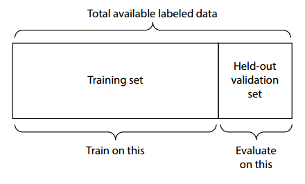

2. *Leave-one-out cross-validation* (LOOCV). Like with previous approach, LOOCV involves splitting the set of observations into two parts. But this time we only use a single observation $(y_i, \mathbf x_i)$ for validation, and train the model on the remaining observations to obtain a single held-out prediction ($y_i^\text{pred}$). We repeat this procedure on the $n - 1$ remaining observations and average all test error estimates to obtain a final estimate which solves for both drawbacks in the previous approach.

   $$\text{CV}_{(n)} = \frac{1}{n} \sum_{i = 1}^n \text{error}_i$$

   Unfortunately, this procedure is computationally very expensive, which explains why it isn’t used by Deep Learning practitioners.
3. *$k$-fold cross-validation*. This approach involves randomly dividing the set of observations into $k$ groups (or *folds*) of approximately equal size. The first fold is treated as a validation set, and the model is fitted on the remaining $k − 1$ folds. Much like with LOOCV, this procedure is repeated $k$ times.

   $$\text{CV}_{(k)} = \frac{1}{k} \sum_{i = 1}^k \text{error}_i$$

   Or schematically:

[figure not shown]

4. *Iterated $k$-fold cross-validation with shuffling*. It consists of applying $k$-fold validation multiple times, shuffling the data every time before splitting it $k$ ways. The final score is the average of the scores obtained at each run of $k$-fold validation. This is closer to LOOCV, which means it’s also more computationally expensive. Note that you end up training and evaluating $P \times K$ models (where $P$ is the number of iterations you use).

## 1<sup>st</sup> Example: Classification

In this example we try to classify movie reviews as positive or negative. Here’s a small summary of the main takeaways>

- Text data requires a lot of preprocessing before feeding it (as tensors) into a neural network. Most of the time, sequences of words are encoded as binary vectors, but there are other encoding options.
- Stacks of dense layers with `relu` activations can solve a wide range of problems.
- In a binary classification problem, the network should end with a dense layer with one unit and a `sigmoid` activation: this turns the output into a scalar between 0 and 1 (i.e. a probability). In this case, the appropriate loss function is `binary_crossentropy`.
- The `rmsprop` optimizer is almost always a good enough choice.
- Thre are three popular strategies for dealing with overfitting.

```r
library(keras)
imdb <- dataset_imdb(num_words = 10000)
```

The IMDB dataset comes packaged with Keras. It has already been preprocessed: the reviews (sequences of words) have been turned into sequences of integers, where each integer stands for a specific word in a dictionary.

```r
## First 5 reviews from the training set
tibble(y = imdb$train$y[1:5],
       x = imdb$train$x[1:5])
```

```
# A tibble: 5 x 2
      y x
  <int> <list>
1     1 <int [218]>
2     0 <int [189]>
3     0 <int [141]>
4     1 <int [550]>
5     0 <int [147]>
```

Thus, each review is a list of *word indices*, encoding a sequence of words.

For example, this…

```r
imdb$train$x[[6]]
```

```
 [1]    1  778  128   74   12  630  163   15    4 1766 7982 1051    2   32
[15]   85  156   45   40  148  139  121  664  665   10   10 1361  173    4
[29]  749    2   16 3804    8    4  226   65   12   43  127   24    2   10
[43]   10
```

```r
word_index <- dataset_imdb_word_index() %>%
  unlist()

decode <- function(index) {
  # Note that the indices are offset by 3 because 0, 1, and 2 are
  # reserved indices for "padding", "start of sequence", and "unknown".
  word <- if (index >= 3) names(word_index[word_index == index - 3])
  if (is.null(word)) "[?]" else word
}

imdb$train$x[[7]] %>%
  map_chr(decode) %>%
  cat()
```

```
[?] lavish production values and solid performances in this straightforward adaption of jane [?] satirical classic about the marriage game within and between the classes in [?] 18th century england northam and paltrow are a [?] mixture as friends who must pass through [?] and lies to discover that t…
```

```r
tibble(y = imdb$train$y[1:10],
       x = imdb$train$x[1:10]) %>%
  mutate(review = x %>% map(function(x) map_chr(x,decode))) %>%
  mutate(review = map_chr(review, function(x) paste0(x, collapse = " ")))
```

```
# A tibble: 10 x 3
       y x          review
   <int> <list>     <chr>
 1     1 <int [218… [?] this film was just brilliant casting location scen…
 2     0 <int [189… [?] big hair big boobs bad music and a giant safety pi…
 3     0 <int [141… [?] this has to be one of the worst films of the 1990s…
 4     1 <int [550… [?] the [?] [?] at storytelling the traditional sort m…
 5     0 <int [147… [?] worst mistake of my life br br i picked this movie…
 6     0 <int [43]> [?] begins better than it ends funny that the russian …
 7     1 <int [123… [?] lavish production values and solid performances in…
 8     0 <int [562… [?] the [?] tells the story of the four hamilton sibli…
 9     1 <int [233… [?] just got out and cannot believe what a brilliant d…
10     0 <int [130… [?] this movie has many problem associated with it tha…
```

**Preparing the data**

The lists of word indices must first be turned into tensors, so that we can feed them into a neural network. Here, we turn each IMDB review into a vector of size 10,000 whose elements consist on 0s and 1s (also known as “one-hot encoding”).

```r
vectorize_sequences <- function(sequences, dimension = 10000) {
  results <- matrix(0, nrow = length(sequences), ncol = dimension)

  for (i in 1:length(sequences)) {
    results[i, sequences[[i]]] <- 1
  }
  return(results)
}

## Training data
x_train <- vectorize_sequences(imdb$train$x)
y_train <- as.numeric(imdb$train$y)

## Testing data
x_test <- vectorize_sequences(imdb$test$x)
y_test <- as.numeric(imdb$test$y)

colnames(x_train) <- c(rep("[?]", 3), names(sort(word_index)[1:9997]))
colnames(x_test) <- c(rep("[?]", 3), names(sort(word_index)[1:9997]))

x_train[1:10, 11:21]
```

```
      in it i this that was as for with movie but
 [1,]  0  1 1    1    1   1  1   1    1     0   1
 [2,]  1  0 1    1    1   1  0   1    1     1   1
 [3,]  1  1 1    1    1   1  0   1    1     0   1
 [4,]  1  1 1    1    1   1  1   0    1     0   1
 [5,]  1  1 1    1    1   1  0   1    1     1   0
 [6,]  0  1 0    0    1   1  0   0    0     0   0
 [7,]  1  1 1    1    1   0  1   0    0     0   0
 [8,]  1  1 1    1    1   1  1   1    1     0   1
 [9,]  1  1 1    1    1   1  0   0    1     1   1
[10,]  1  1 1    1    1   1  0   1    1     1   0
```

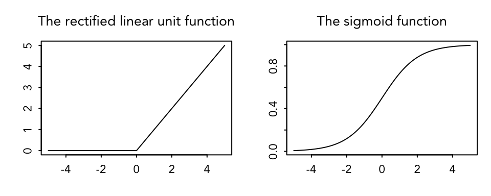

```r
## Set up the model
model <- keras_model_sequential() %>%
  layer_dense(units = 16, activation = "relu", input_shape = c(10000)) %>%
  layer_dense(units = 16, activation = "relu") %>%
  layer_dense(units = 1, activation = "sigmoid")

model
```

```
Model
___________________________________________________________________________
Layer (type)                     Output Shape                  Param #
===========================================================================
dense (Dense)                    (None, 16)                    160016
___________________________________________________________________________
dense_1 (Dense)                  (None, 16)                    272
___________________________________________________________________________
dense_2 (Dense)                  (None, 1)                     17
===========================================================================
Total params: 160,305
Trainable params: 160,305
Non-trainable params: 0
___________________________________________________________________________
```